# Bayesian models for paired comparisons and rankings with RBBayes

A hands-on tutorial

Lapo Santi and Nial Friel

# 1 Before you start

This document is a self-contained tutorial. Every number and figure below is produced by the code in the document, so you can **knit it on your own computer** (RStudio: *Knit* button, or `rmarkdown::render("RBBayes-tutorial.Rmd")`) and obtain the same results. Knitting takes about two minutes on a laptop.

**In the lecture** the slides follow this file in order. Each code slide names the chunk to run (e.g. `fit-bt`); the slides show exactly the code in this file, so your numbers and figures will match the ones on the screen. In RStudio, run a chunk with the green arrow or Ctrl/Cmd + Shift + Enter, and use *Run All Chunks Above* if you fall behind.

**Installation (run once).** RBBayes contains a little C++ code, so you need the standard R build tools: Rtools on Windows, or the Xcode command-line tools on macOS (`xcode-select --install` in a terminal).

```r
install.packages(c("remotes", "ggplot2", "knitr", "rmarkdown"))
remotes::install_github("lapo-santi/RBBayes")

# Optional, used in a few sections (each is skipped if not installed):
install.packages(c("coda", "bayesplot", "salso"))
```

A copy of this file is installed with the package:

```r
file.copy(system.file("tutorial", "RBBayes-tutorial.Rmd", package = "RBBayes"), ".")
```

```r
library(RBBayes)
library(ggplot2)
has_coda      <- requireNamespace("coda", quietly = TRUE)
has_bayesplot <- requireNamespace("bayesplot", quietly = TRUE)
```

**What you will do.** We analyse two pairwise-comparison datasets:

1. a **synthetic tennis league** whose true tiers we know, so we can check what the models recover;
2. a **real season of ATP men’s tennis** (2017), bundled with the package.

For each, we first *explore the data*, then fit a standard Bradley–Terry (BT) model and a Bradley–Terry stochastic block model (BT–SBM). A short final section shows the same workflow for **rankings** with the Plackett–Luce model.

## 1.1 Notation

| Symbol | Meaning |
| --- | --- |
| $n$; $i, j \in \{1, \ldots, n\}$ | number of items (players); item indices |
| $y_{ij}$ | number of wins of $i$ over $j$ |
| $n_{ij} = y_{ij} + y_{ji}$ | number of comparisons between $i$ and $j$ |
| $\lambda_i > 0$ | strength of item $i$ in the standard BT model |
| $z_i \in \{1, \ldots, K\}$ | block (tier) membership of item $i$ in the BT–SBM |
| $\lambda_k > 0$ | strength shared by all items in block $k$ |
| $K$ | number of occupied blocks |

The BT model says
$$y_{ij} \mid \lambda \sim \operatorname{Binomial}\!\left(n_{ij},
\frac{\lambda_i}{\lambda_i + \lambda_j}\right),$$
and the BT–SBM simply replaces $\lambda_i$ by $\lambda_{z_i}$: players in the same block share one strength, so they beat each other with probability 1/2.

# 2 Dataset 1: a synthetic tennis league

## 2.1 Simulate the data

Twenty fictional players are split into four tiers of five players. Players in a tier share a strength; the strengths are `12, 6, 2, 1`. Each pair plays 20 matches.

```r
true_strength <- c(12, 6, 2, 1)
edges <- tennis_tiered_toy(
  n_blocks = 4, latent_strength = true_strength,
  players_per_block = 5, matches_per_pair = 20,
  seed = 101, format = "edgelist"
)
truth <- attr(edges, "truth")   # true tier and strength of each player
head(edges)
```

| winner | loser | count |
| --- | --- | --- |
| Isla Kent | Tara Fox | 8 |
| Isla Kent | Will Gray | 6 |
| Isla Kent | Jack Ford | 3 |
| Isla Kent | Rosa Hill | 12 |
| Isla Kent | Maya Cole | 11 |
| Isla Kent | Leo Wood | 6 |

The data are an **edge list**: one row per (winner, loser) pair, with the number of wins in `count`. `as_bt_data()` turns it into the win-count matrix used by every fitting function.

```r
tennis <- as_bt_data(edges, count = "count")
tennis
```

```
## <btsbm_pairwise_data> 20 items and 3800 wins
```

```r
tennis$wins[1:5, 1:5]      # wins[i, j] = wins of row player i over column player j
```

```
##           Isla Kent Tara Fox Will Gray Jack Ford Rosa Hill
## Isla Kent         0        8         6         3        12
## Tara Fox         12        0        15         9        14
## Will Gray        14        5         0         5         4
## Jack Ford        17       11        15         0         8
## Rosa Hill         8        6        16        12         0
```

**Are the true strengths on the scale of the prior?** Below we give every strength a Gamma(`shape_lambda` = 2, `rate_lambda` = $e^{\psi(2)}$) prior; this rate makes $E[\log \lambda] = 0$, so a typical strength is about 1. Only ratios of strengths matter, so compare the *ratios* $12/1$ with what the prior finds plausible:

```r
shape_lambda <- 2
rate_lambda  <- exp(digamma(shape_lambda))
prior_draws  <- rgamma(1e5, shape = shape_lambda, rate = rate_lambda)
quantile(prior_draws, c(0.05, 0.5, 0.95))
```

```
##        5%       50%       95%
## 0.2324822 1.1031789 3.1099660
```

```r
# Ratio of the 95% to the 5% prior quantile versus the largest true ratio:
c(prior_ratio = unname(quantile(prior_draws, 0.95) / quantile(prior_draws, 0.05)),
  true_ratio  = max(true_strength) / min(true_strength))
```

```
## prior_ratio  true_ratio
##    13.37722    12.00000
```

The true strength ratio is within the range the prior considers plausible. A generating vector such as `c(64, 16, 4, 1)` would put the strongest tier far in the prior’s tail, and would also make the example unrealistically easy.

## 2.2 Explore the data first

Before fitting anything, look at the raw outcomes.

```r
n_ij <- tennis$wins + t(tennis$wins)
player_table <- data.frame(
  player  = tennis$item_labels,
  matches = rowSums(n_ij),
  wins    = rowSums(tennis$wins)
)
player_table$win_rate <- round(player_table$wins / player_table$matches, 3)
player_table <- player_table[order(-player_table$win_rate), ]
rownames(player_table) <- NULL
head(player_table, 8)
```

| player | matches | wins | win_rate |
| --- | --- | --- | --- |
| Kira Lane | 380 | 290 | 0.763 |
| Dan Moss | 380 | 289 | 0.761 |
| Noah Bell | 380 | 282 | 0.742 |
| Leo Wood | 380 | 280 | 0.737 |
| Jack Ford | 380 | 269 | 0.708 |
| Tara Fox | 380 | 234 | 0.616 |
| Alex Vale | 380 | 231 | 0.608 |
| Rosa Hill | 380 | 230 | 0.605 |

```r
c(players = tennis$n_items,
  pairs_compared = sum(n_ij[upper.tri(n_ij)] > 0),
  matches = sum(tennis$wins))
```

```
##        players pairs_compared        matches
##             20            190           3800
```

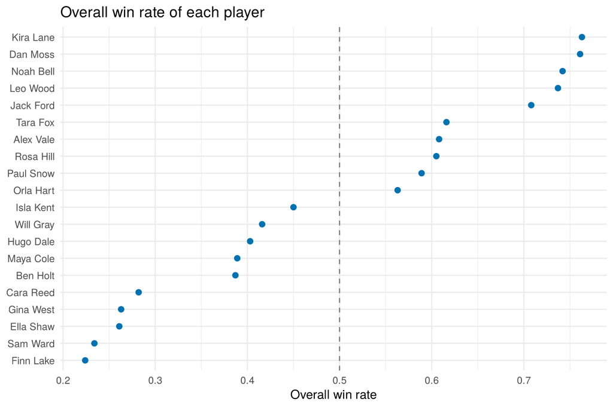

```r
ggplot(player_table, aes(x = win_rate, y = reorder(player, win_rate))) +
  geom_point(colour = "#0072B2", size = 2) +
  geom_vline(xintercept = 0.5, linetype = "dashed", colour = "grey50") +
  labs(x = "Overall win rate", y = NULL,
       title = "Overall win rate of each player") +
  theme_minimal()
```

The win rates already suggest groups of players, but the gaps are not clean.

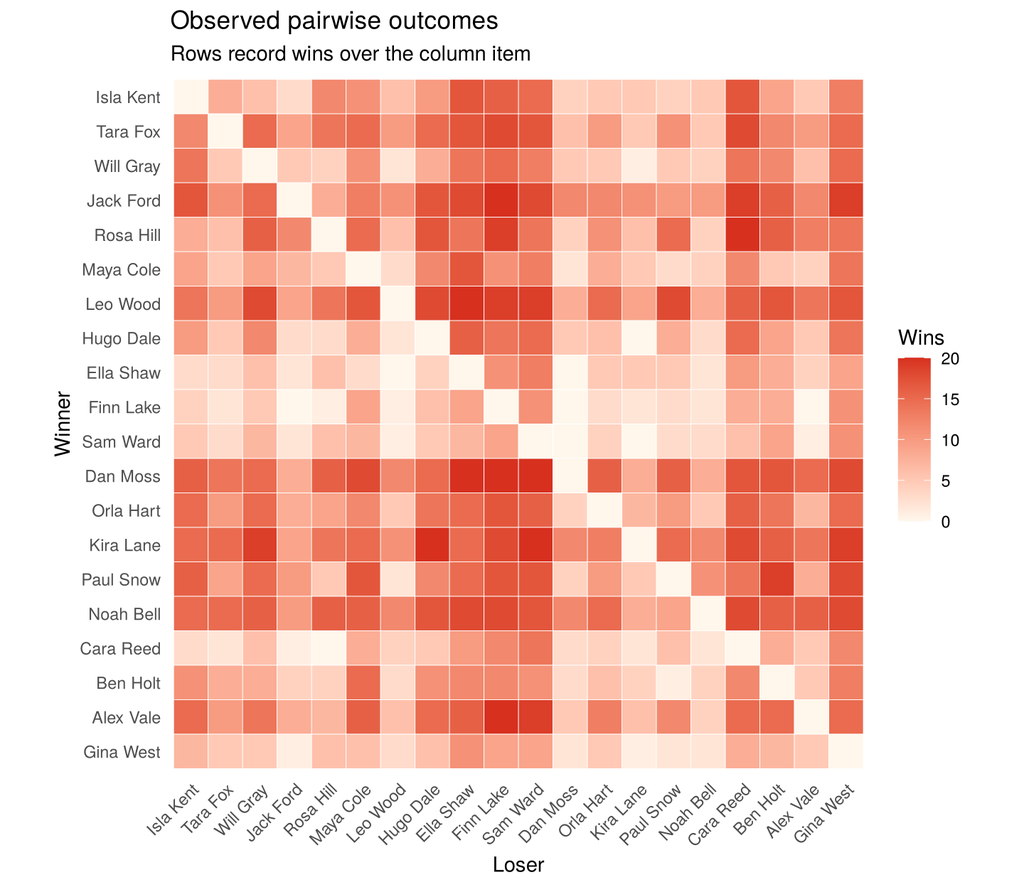

```r
plot_pairwise_outcomes(tennis)
```

Both axes use the same (random) player order, so no structure is visible yet. Keep this picture in mind: after fitting the block model we will redraw it with players ordered by their estimated tier.

## 2.3 The standard Bradley–Terry model

Each player gets their own strength $\lambda_i \overset{iid}{\sim}$ Gamma(`shape_lambda`, `rate_lambda`). In `bt_model()` you only give `shape_lambda` and `rate_lambda`.

```r
bt_fit <- fit_model(
  tennis,
  bt_model(shape_lambda = 2, rate_lambda = exp(digamma(2))),
  mcmc_control(iter = 4000, warmup = 2000, seed = 12)
)
bt_fit
```

```
## <btsbm_fit> Bradley-Terry (BT), one strength per item
##   20 items; 2000 retained posterior draws. Use summary() for results.
```

```r
summary(bt_fit)
```

```
## Model:   Bradley-Terry (BT), one strength per item
## Data:    20 items, 190 compared pairs, 3800 comparisons
## Priors:  lambda_i ~ iid Gamma(shape_lambda = 2, rate_lambda = 1.526)
## MCMC:    4000 iterations, 2000 warm-up, 2000 retained draws (2.9 s)
##
## Relative strengths (share of total strength), 90% credible intervals:
##       item  mean median lower upper
##  Kira Lane 0.123  0.122 0.103 0.144
##   Dan Moss 0.121  0.121 0.101 0.142
##  Noah Bell 0.109  0.108 0.090 0.130
##   Leo Wood 0.106  0.105 0.088 0.125
##  Jack Ford 0.092  0.092 0.076 0.107
##   Tara Fox 0.060  0.060 0.050 0.071
##  Alex Vale 0.058  0.058 0.048 0.069
##  Rosa Hill 0.057  0.057 0.047 0.068
##  Paul Snow 0.054  0.053 0.044 0.063
##  Orla Hart 0.047  0.047 0.039 0.057
##   ... 10 more items; see strength_summary().
```

`iter` counts all iterations, `warmup` of them are discarded, and the remaining `iter - warmup` draws are kept.

### 2.3.1 Relative strengths

The likelihood only depends on ratios $\lambda_i/\lambda_j$, so we report the **relative strength** of each player: their share of the total strength in each draw, $\lambda_i / \sum_j \lambda_j$. Shares add to one; the dashed line marks $1/n$, the share every player would have if all were equal.

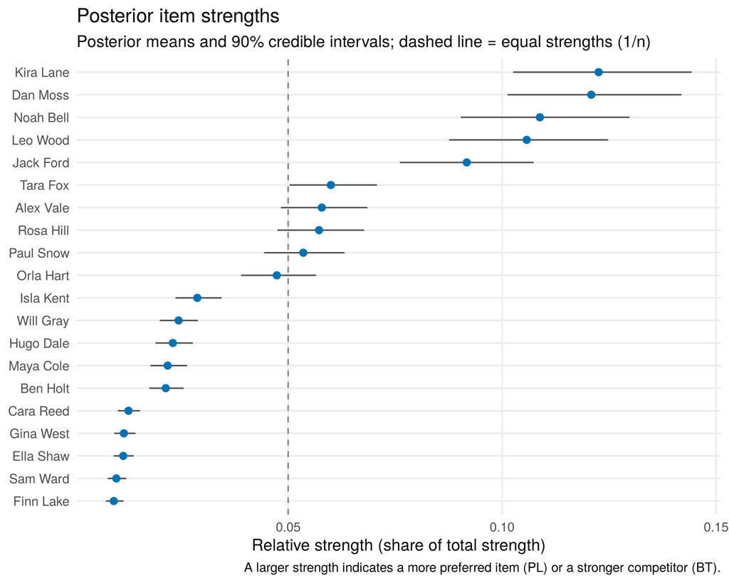

```r
plot_strength_summary(bt_fit)
```

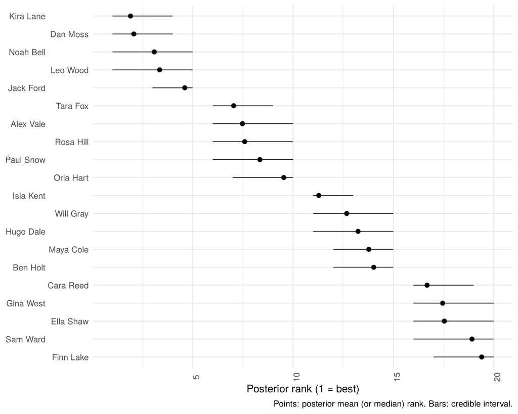

```r
plot_rank_intervals(bt_fit)
```

### 2.3.2 Who is stronger than whom? $\Pr(\lambda_i > \lambda_j \mid y)$

Rankings hide how sure we are about each comparison. `prob_stronger()` returns, for every pair, the posterior probability that the row player is stronger than the column player.

```r
p_bt <- prob_stronger(bt_fit)
round(p_bt[1:5, 1:5], 2)
```

```
##           Kira Lane Dan Moss Noah Bell Leo Wood Jack Ford
## Kira Lane        NA     0.54      0.77     0.82      0.97
## Dan Moss       0.46       NA      0.73     0.79      0.96
## Noah Bell      0.23     0.27        NA     0.56      0.85
## Leo Wood       0.18     0.21      0.44       NA      0.82
## Jack Ford      0.03     0.04      0.15     0.18        NA
```

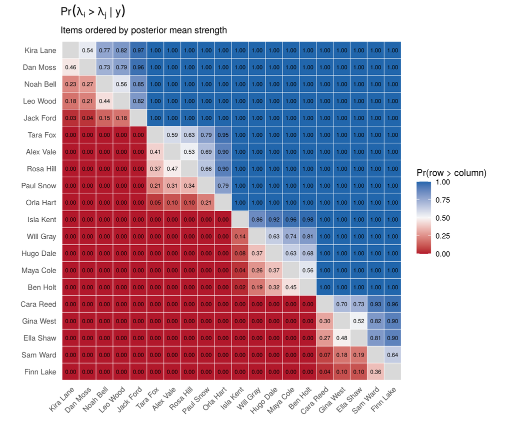

```r
plot_prob_stronger(bt_fit)
```

The colour scale is centred at 0.5: white cells are pairs the data cannot separate. Under the standard BT model, players from the same true tier often have probabilities between 0.2 and 0.8 — the model gives them distinct strengths but cannot say which one is larger.

### 2.3.3 Checking the MCMC

Convergence checks use the same relative strengths. Columns are named after the players, e.g. `rel_strength[Kira Lane]`.

```r
draws <- as.matrix(bt_fit)
dim(draws)
```

```
## [1] 2000   20
```

```r
colnames(draws)[1:4]
```

```
## [1] "rel_strength[Isla Kent]" "rel_strength[Tara Fox]"
## [3] "rel_strength[Will Gray]" "rel_strength[Jack Ford]"
```

```r
top_players <- paste0("rel_strength[", head(strength_summary(bt_fit)$item, 4), "]")
top_players
```

```
## [1] "rel_strength[Kira Lane]" "rel_strength[Dan Moss]"
## [3] "rel_strength[Noah Bell]" "rel_strength[Leo Wood]"
```

```r
chain <- coda::as.mcmc(bt_fit)
round(coda::effectiveSize(chain)[top_players])
```

```
## rel_strength[Kira Lane]  rel_strength[Dan Moss] rel_strength[Noah Bell]
##                     330                     317                     257
##  rel_strength[Leo Wood]
##                     305
```

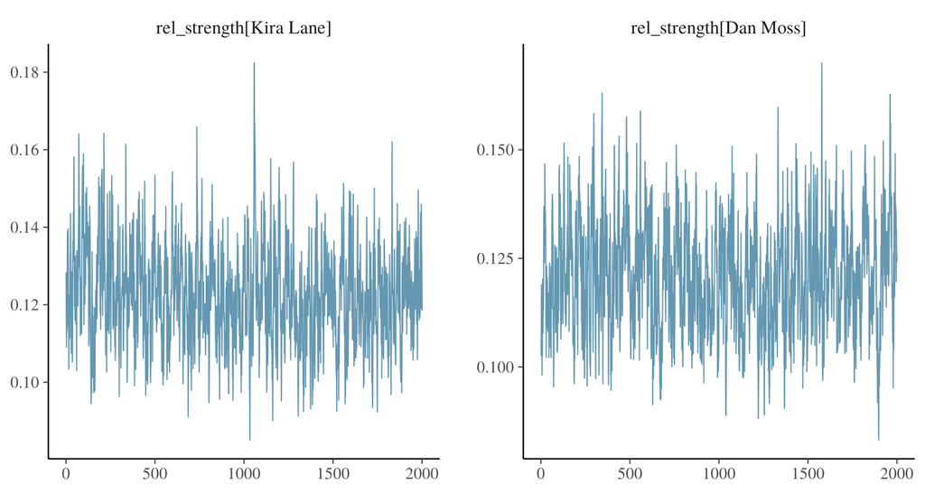

```r
bayesplot::mcmc_trace(bt_fit, pars = top_players[1:2])
```

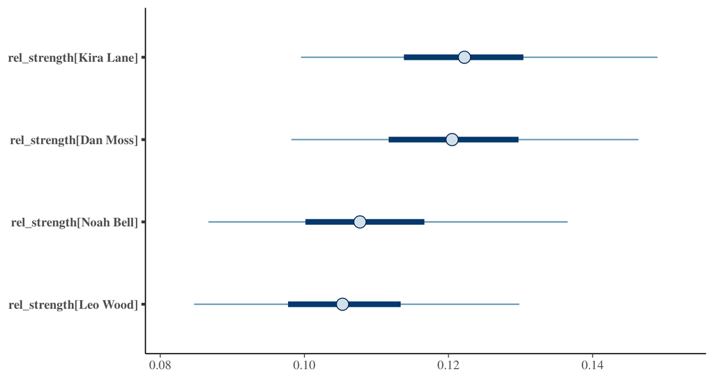

```r
bayesplot::mcmc_intervals(bt_fit, pars = top_players, prob = 0.5, prob_outer = 0.95)
```

A single chain cannot reveal every problem. Run a second, independent chain with a different seed and compare:

```r
bt_fit2 <- fit_model(tennis, bt_fit$model,
                     mcmc_control(iter = 4000, warmup = 2000, seed = 112))
chains <- as_mcmc_chains(list(bt_fit, bt_fit2))
coda::gelman.diag(chains[, top_players], autoburnin = FALSE, multivariate = FALSE)
```

```
## Potential scale reduction factors:
##
##                         Point est. Upper C.I.
## rel_strength[Kira Lane]       1.00       1.02
## rel_strength[Dan Moss]        1.00       1.00
## rel_strength[Noah Bell]       1.01       1.06
## rel_strength[Leo Wood]        1.00       1.02
```

Values of the potential scale reduction factor close to 1 are reassuring.

## 2.4 The Bradley–Terry stochastic block model

The BT–SBM groups players into blocks: $z_i$ is the block of player $i$, $\lambda_k \overset{iid}{\sim}$ Gamma(`shape_lambda`, `rate_lambda`) is the strength of block $k$, and the partition $z$ gets a prior that leaves the number of blocks $K$ random.

### 2.4.1 Prior on the number of blocks

Before seeing data, how many blocks does each partition prior expect among $n = 20$ players?

```r
priors <- list(
  Gnedin       = gnedin_prior(gnedin_hyper = 0.5),
  DP           = dirichlet_process_prior(concentration = 1),
  PitmanYor    = pitman_yor_prior(concentration = 1, discount = 0.2),
  DirMult_max4 = dirichlet_multinomial_prior(max_clusters = 4, concentration = 1)
)
data.frame(
  prior        = names(priors),
  prior_mean_K = round(sapply(priors, function(p) prior_mean_K(20, p)), 2),
  row.names    = NULL
)
```

| prior | prior_mean_K |
| --- | --- |
| Gnedin | 3.99 |
| DP | 3.60 |
| PitmanYor | 4.97 |
| DirMult_max4 | 3.48 |

```r
# Prior standard deviations are available for the Gnedin and DP priors:
sqrt(c(Gnedin = prior_variance_K(20, priors$Gnedin),
       DP     = prior_variance_K(20, priors$DP)))
```

```
##   Gnedin       DP
## 5.096106 1.414771
```

We use the Gnedin prior, which allows a random but finite number of blocks and, with its large prior standard deviation, is not very informative about $K$.

### 2.4.2 Fit

```r
sbm_model <- bt_sbm_model(
  shape_lambda = 2, rate_lambda = exp(digamma(2)),
  item_clustering = gnedin_prior(gnedin_hyper = 0.5)
)
sbm_model
```

```
## <btsbm_model> Bradley-Terry stochastic block model (BT-SBM), items share block strengths
##   strength prior:   lambda_k ~ iid Gamma(shape_lambda = 2, rate_lambda = 1.526)
##   item partition:    z ~ Gnedin(gnedin_hyper = 0.5)
```

```r
sbm_fit <- fit_model(tennis, sbm_model,
                     mcmc_control(iter = 10000, warmup = 5000, seed = 2))
summary(sbm_fit)
```

```
## Model:   Bradley-Terry stochastic block model (BT-SBM), items share block strengths
## Data:    20 items, 190 compared pairs, 3800 comparisons
## Priors:  lambda_k ~ iid Gamma(shape_lambda = 2, rate_lambda = 1.526)
##          item partition z ~ Gnedin(gnedin_hyper = 0.5)
## MCMC:    10000 iterations, 5000 warm-up, 5000 retained draws (7.5 s)
##
## Posterior number of blocks, Pr(K = k | y):
##     4     5     6     7     8     9    10
## 0.583 0.271 0.099 0.032 0.011 0.004 0.001
##
## Point estimate of the partition (block 1 = strongest):
##   Block 1 (5 items): Jack Ford, Leo Wood, Dan Moss, Kira Lane, Noah Bell
##   Block 2 (5 items): Tara Fox, Rosa Hill, Orla Hart, Paul Snow, Alex Vale
##   Block 3 (5 items): Isla Kent, Will Gray, Maya Cole, Hugo Dale, Ben Holt
##   Block 4 (5 items): Ella Shaw, Finn Lake, Sam Ward, Cara Reed, Gina West
```

In a block model, individual strengths are not the natural summary (players in a block share one value, and block labels change between draws), so the summary reports the number of blocks and the estimated partition instead.

### 2.4.3 How many blocks?

```r
posterior_K_table(sbm_fit)
```

| K | draws | probability |
| --- | --- | --- |
| 4 | 2915 | 0.5830 |
| 5 | 1357 | 0.2714 |
| 6 | 496 | 0.0992 |
| 7 | 158 | 0.0316 |
| 8 | 53 | 0.0106 |
| 9 | 18 | 0.0036 |
| 10 | 3 | 0.0006 |

The truth, $K = 4$, is the most probable value, but there is real posterior mass on 5 or more blocks: with strengths 12 vs 6 and 2 vs 1 the tiers are not perfectly separated by 20 matches per pair.

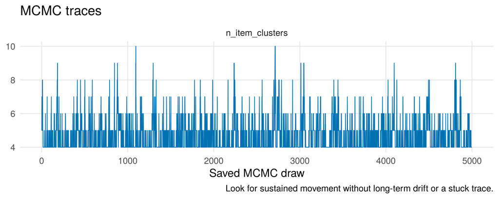

```r
plot_mcmc_traces(sbm_fit)
```

### 2.4.4 The estimated partition and the reordered data

`partition_point_estimate()` summarises the posterior over partitions by the partition minimising the posterior expected variation of information (VI). Block 1 is the strongest. Compare with the truth:

```r
z_hat <- partition_point_estimate(sbm_fit)
table(estimated_block = z_hat,
      true_tier = truth$true_block[match(names(z_hat), truth$item)])
```

```
##                true_tier
## estimated_block 1 2 3 4
##               1 5 0 0 0
##               2 0 5 0 0
##               3 0 0 5 0
##               4 0 0 0 5
```

Now redraw the outcome matrix with players ordered by their estimated block:

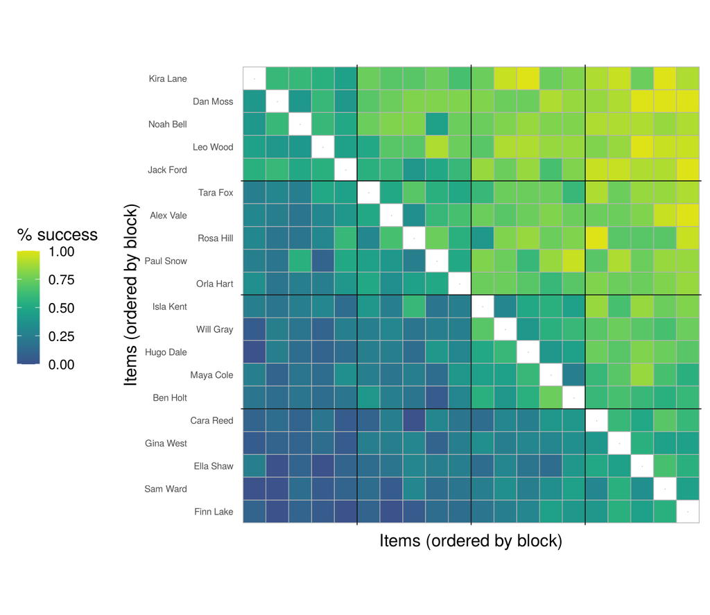

```r
plot_ordered_adjacency(sbm_fit, z_hat = z_hat, clean_fun = NULL)
```

The block structure that was invisible in the raw matrix is now obvious.

### 2.4.5 Membership probabilities

`plot_assignment_probabilities()` shows, for each player, the posterior probability of belonging to each block, **conditional on a given number of blocks** $K$ (block labels are only comparable across draws with the same $K$). The colour scale is centred at 0.5: blue means “more likely than not”.

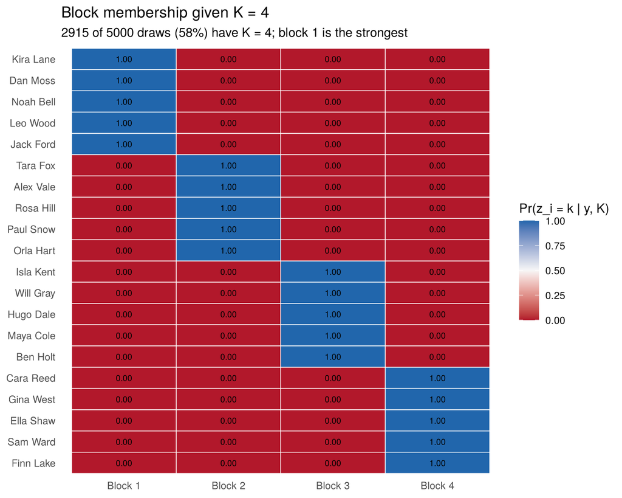

```r
plot_assignment_probabilities(sbm_fit, k_show = 4, clean_fun = NULL)
```

Given $K = 4$, every draw has the same partition (the true one), so all probabilities are 0 or 1. This does **not** mean the partition is certain: about 40% of the draws have more than four blocks, and they are excluded here. Look at the draws with five blocks:

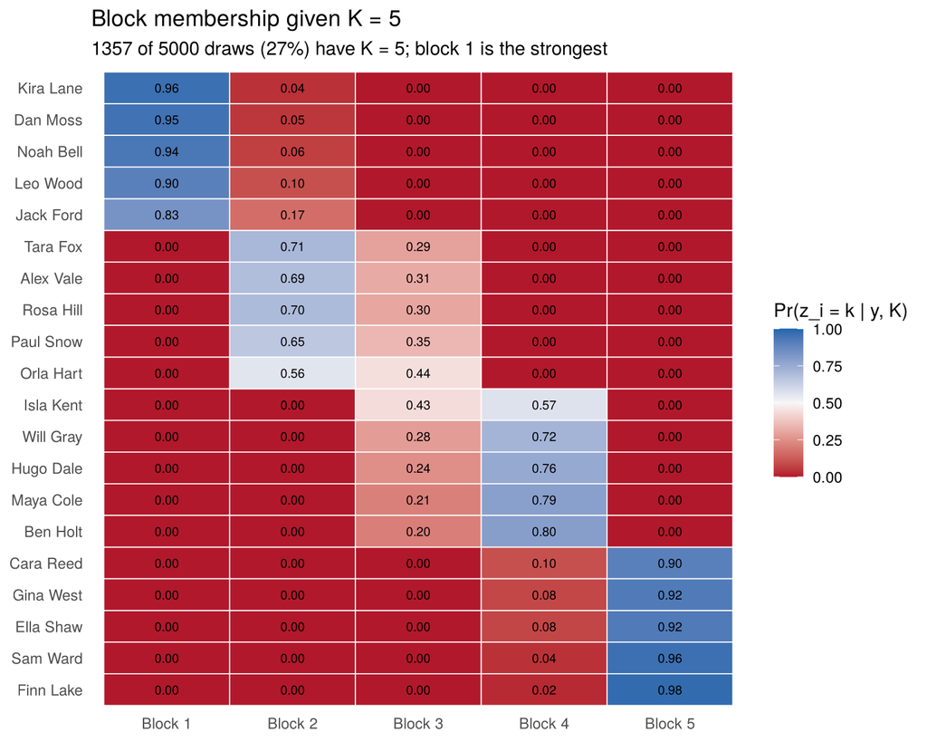

```r
plot_assignment_probabilities(sbm_fit, k_show = 5, clean_fun = NULL)
```

With five blocks, one of the true tiers is split into two sub-blocks. Any tier can be split, most often the middle ones (strengths 6 and 2), so several players have probabilities between 0.2 and 0.8: white-ish cells mark players whose sub-block is genuinely uncertain.

### 2.4.6 Which players belong together?

The posterior similarity matrix does not condition on $K$: cell $(i, j)$ is $\Pr(z_i = z_j \mid y)$, the proportion of all draws in which the two players share a block. Outlines show the estimated partition.

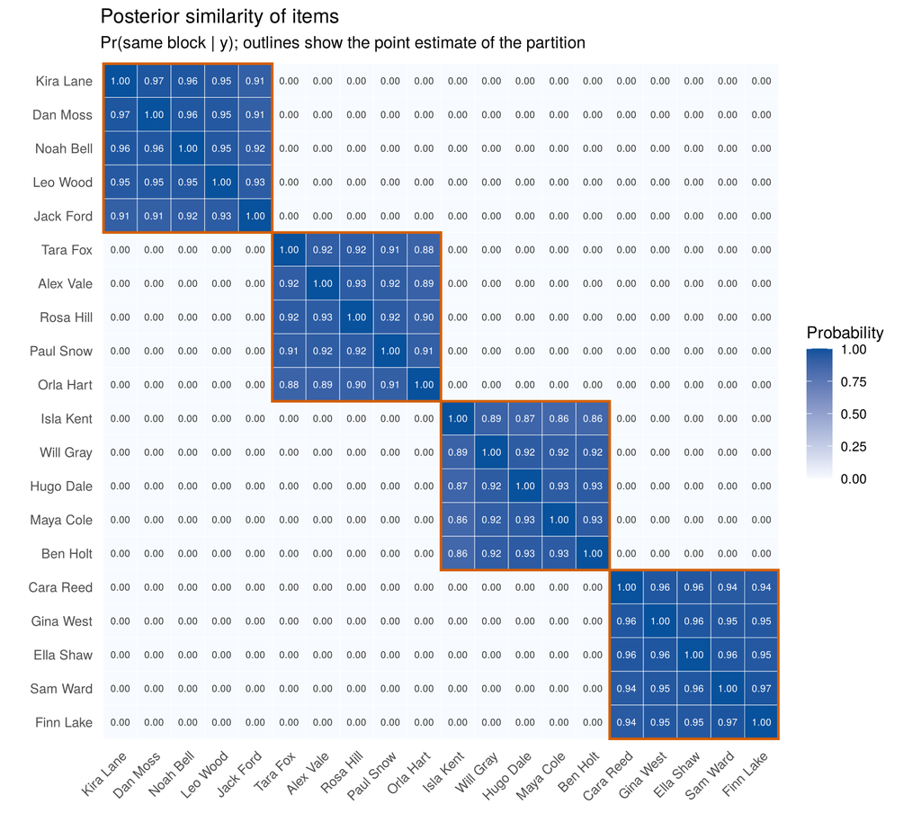

```r
plot_posterior_similarity(sbm_fit)
```

Within each outlined block the probabilities are around 0.85–0.97, and they are **zero** outside. Where does the missing probability go? Not to other blocks: in the draws where two players of the same tier are separated, the tier has been split into sub-blocks. `block_stability()` makes this explicit:

```r
block_stability(sbm_fit, z_hat)[, c("block", "size", "together", "split", "merged")]
```

| block | size | together | split | merged |
| --- | --- | --- | --- | --- |
| 1 | 5 | 0.8820 | 0.1180 | 0 |
| 2 | 5 | 0.8258 | 0.1742 | 0 |
| 3 | 5 | 0.8076 | 0.1924 | 0 |
| 4 | 5 | 0.9126 | 0.0874 | 0 |

`merged` is zero for every block: no draw ever puts players from different estimated blocks together. All the uncertainty is about splitting tiers, which is exactly what the $K = 5$ membership plot showed.

### 2.4.7 Credible ball for the partition

A credible ball (Wade & Ghahramani, 2018) is the smallest VI ball around $\hat z$ that contains 95% of the posterior draws. Its bounds describe the coarsest and finest partitions that remain plausible.

```r
cb <- credible_ball(sbm_fit, z_hat = z_hat, credible_mass = 0.95)
cb
```

```
## <credible ball for the item partition z>
##   95% ball, VI radius 0.485 (contains 95.5% of draws; method: native)
##   Number of blocks K:
##     point estimate        4
##     upper vertical bound  4  (coarsest partition in the ball)
##     lower vertical bound  7  (finest partition in the ball)
##     horizontal bound      6  (furthest partition from the estimate)
```

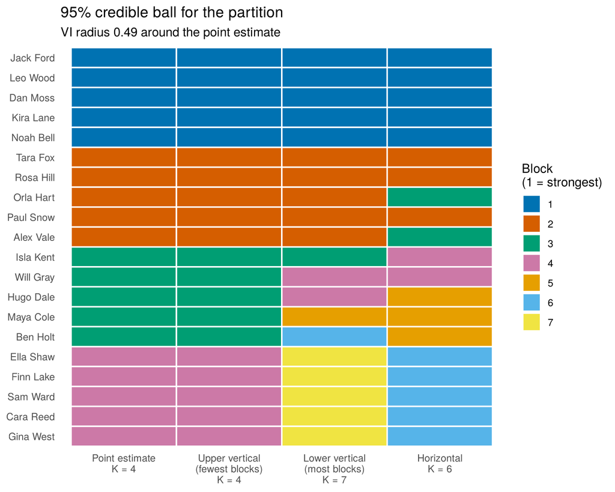

```r
plot_credible_ball(cb)
```

If the GitHub package `mcclust.ext` is installed, `credible_ball(sbm_fit, method = "mcclust.ext")` computes the same summary with Wade’s reference implementation.

### 2.4.8 $\Pr(\lambda_i > \lambda_j \mid y)$ in the block model

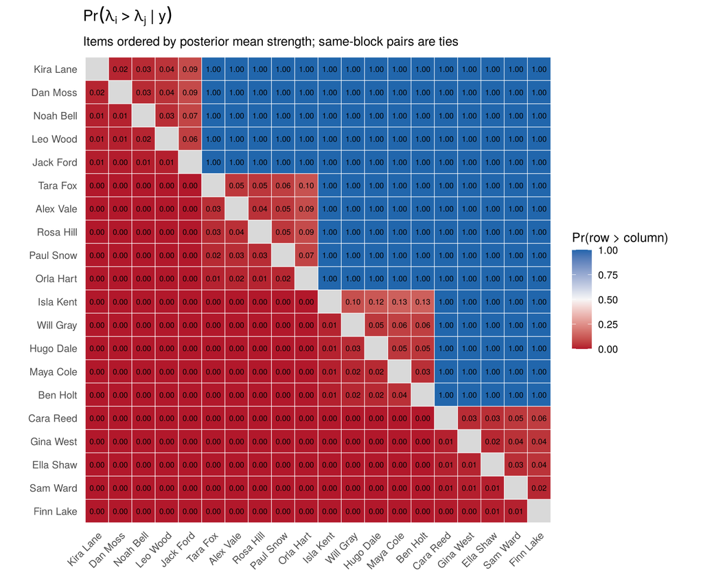

```r
plot_prob_stronger(sbm_fit)
```

Compare with the standard BT model: between tiers the block model is close to certain, while within a tier the two players are usually *tied* ($\lambda_{z_i} = \lambda_{z_j}$), so both $\Pr(\lambda_i > \lambda_j)$ and $\Pr(\lambda_j > \lambda_i)$ are small. The tie probability is stored in the `prob_equal` attribute and equals the posterior similarity:

```r
p_sbm <- prob_stronger(sbm_fit)
round(attr(p_sbm, "prob_equal")[1:5, 1:5], 2)
```

```
##           Kira Lane Dan Moss Noah Bell Leo Wood Jack Ford
## Kira Lane        NA     0.97      0.96     0.95      0.91
## Dan Moss       0.97       NA      0.96     0.95      0.91
## Noah Bell      0.96     0.96        NA     0.95      0.92
## Leo Wood       0.95     0.95      0.95       NA      0.93
## Jack Ford      0.91     0.91      0.92     0.93        NA
```

### 2.4.9 A second chain

```r
sbm_fit2 <- fit_model(tennis, sbm_model,
                      mcmc_control(iter = 10000, warmup = 5000, seed = 202))
merge(posterior_K_table(sbm_fit)[, c("K", "probability")],
      posterior_K_table(sbm_fit2)[, c("K", "probability")],
      by = "K", all = TRUE, suffixes = c("_chain1", "_chain2"))
```

| K | probability_chain1 | probability_chain2 |
| --- | --- | --- |
| 4 | 0.5830 | 0.6032 |
| 5 | 0.2714 | 0.2706 |
| 6 | 0.0992 | 0.0934 |
| 7 | 0.0316 | 0.0236 |
| 8 | 0.0106 | 0.0068 |
| 9 | 0.0036 | 0.0016 |
| 10 | 0.0006 | 0.0004 |
| 11 | NA | 0.0002 |
| 12 | NA | 0.0002 |

Similar block-count distributions in independent chains are one useful (but not sufficient) check of convergence.

# 3 Dataset 2: the 2017 ATP season

The package includes head-to-head counts for the 105 top ATP players in each season from 2000 to 2025.

## 3.1 Explore the data

```r
atp <- ATP_2000_2025[["2017"]]
players <- atp$players_df
atp_data <- as_bt_data(atp$Y_ij, item_labels = make.unique(players$player_label))
atp_data
```

```
## <btsbm_pairwise_data> 105 items and 1719 wins
```

```r
n_ij <- atp$N_ij
c(players = nrow(n_ij),
  matches = sum(atp$Y_ij),
  pairs_that_met = sum(n_ij[upper.tri(n_ij)] > 0),
  possible_pairs = choose(nrow(n_ij), 2))
```

```
##        players        matches pairs_that_met possible_pairs
##            105           1719           1363           5460
```

Unlike the synthetic league, most pairs never met: only about one pair in four played each other. The model borrows strength through common opponents.

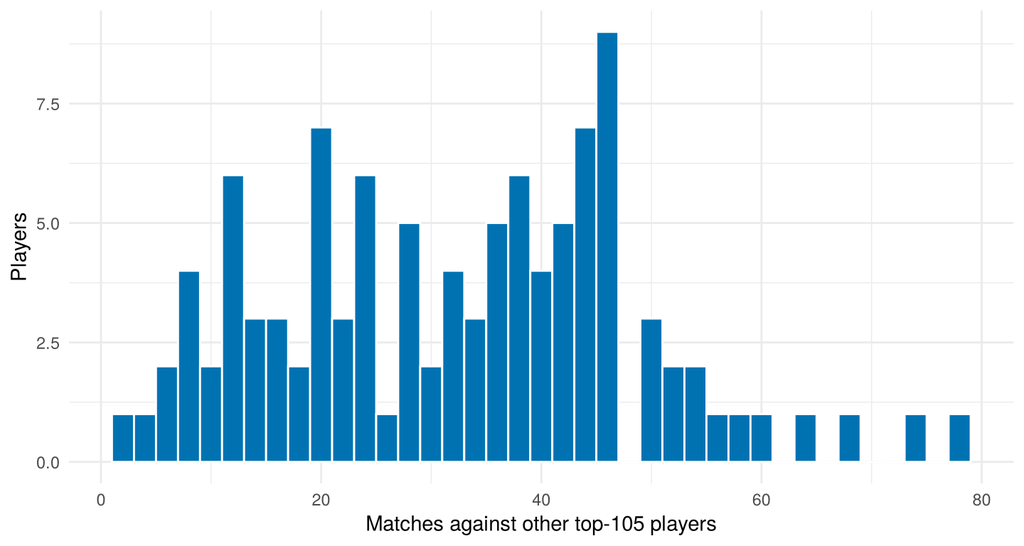

```r
atp_players <- data.frame(
  player = atp_data$item_labels,
  matches = rowSums(n_ij),
  win_rate = rowSums(atp$Y_ij) / rowSums(n_ij),
  year_end_rank = players$last_rank
)
ggplot(atp_players, aes(matches)) +
  geom_histogram(binwidth = 2, fill = "#0072B2", colour = "white") +
  labs(x = "Matches against other top-105 players", y = "Players") +
  theme_minimal()
```

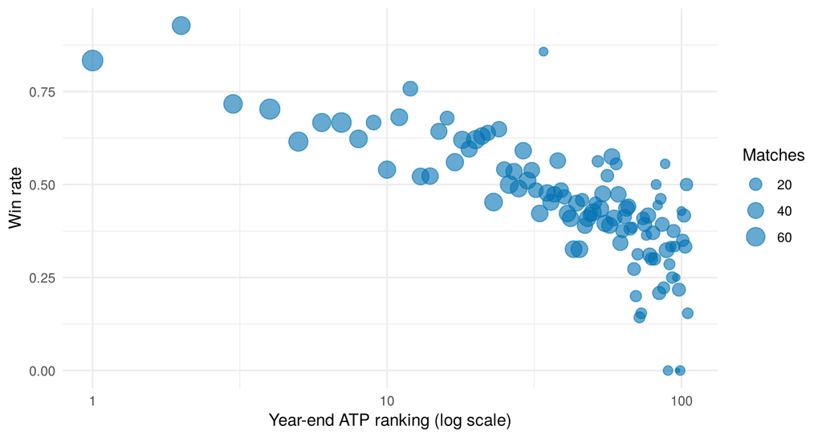

```r
ggplot(atp_players, aes(year_end_rank, win_rate)) +
  geom_point(aes(size = matches), alpha = 0.6, colour = "#0072B2") +
  scale_x_log10() +
  labs(x = "Year-end ATP ranking (log scale)", y = "Win rate",
       size = "Matches") +
  theme_minimal()
```

Win rate falls with ranking, but noisily, especially for players with few matches.

## 3.2 Fit the BT–SBM

```r
atp_fit <- fit_model(
  atp_data,
  bt_sbm_model(shape_lambda = 2, rate_lambda = exp(digamma(2)),
               item_clustering = gnedin_prior(gnedin_hyper = 0.5)),
  mcmc_control(iter = 6000, warmup = 3000, seed = 1)
)
posterior_K_table(atp_fit)
```

| K | draws | probability |
| --- | --- | --- |
| 3 | 467 | 0.1556667 |
| 4 | 891 | 0.2970000 |
| 5 | 726 | 0.2420000 |
| 6 | 481 | 0.1603333 |
| 7 | 219 | 0.0730000 |
| 8 | 103 | 0.0343333 |
| 9 | 65 | 0.0216667 |
| 10 | 17 | 0.0056667 |
| 11 | 17 | 0.0056667 |
| 12 | 7 | 0.0023333 |
| 13 | 4 | 0.0013333 |
| 14 | 2 | 0.0006667 |
| 17 | 1 | 0.0003333 |

The number of tiers is much less certain than in the synthetic league.

```r
atp_z <- partition_point_estimate(atp_fit)
table(atp_z)
```

```
## atp_z
##  1  2  3
##  2 22 81
```

```r
names(atp_z)[atp_z == 1]          # the top tier
```

```
## [1] "Nadal R."   "Federer R."
```

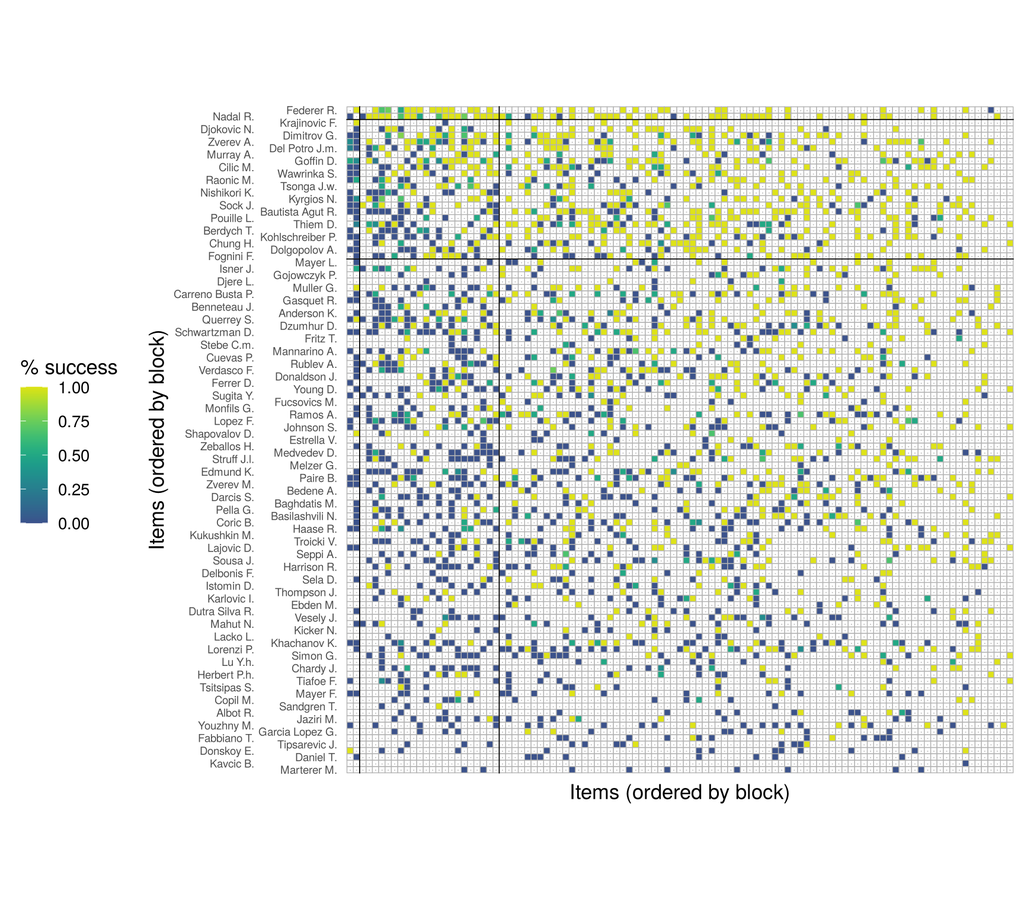

```r
plot_ordered_adjacency(atp_fit, z_hat = atp_z, clean_fun = NULL)
```

Do the estimated tiers agree with the official rankings?

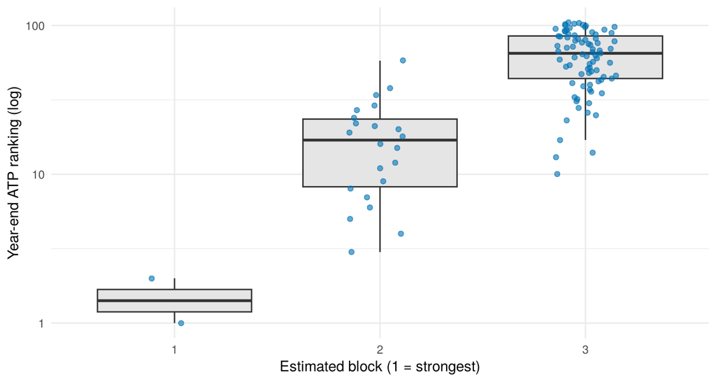

```r
atp_players$block <- factor(atp_z[atp_players$player])
ggplot(atp_players, aes(block, year_end_rank)) +
  geom_boxplot(outlier.shape = NA, fill = "grey90") +
  geom_jitter(width = 0.15, alpha = 0.6, colour = "#0072B2") +
  scale_y_log10() +
  labs(x = "Estimated block (1 = strongest)", y = "Year-end ATP ranking (log)") +
  theme_minimal()
```

## 3.3 Uncertainty about the tiers

```r
atp_cb <- credible_ball(atp_fit, z_hat = atp_z)
atp_cb
```

```
## <credible ball for the item partition z>
##   95% ball, VI radius 2.268 (contains 95.0% of draws; method: native)
##   Number of blocks K:
##     point estimate        3
##     upper vertical bound  3  (coarsest partition in the ball)
##     lower vertical bound  10  (finest partition in the ball)
##     horizontal bound      7  (furthest partition from the estimate)
```

```r
block_stability(atp_fit, atp_z)[, c("block", "size", "together", "split", "merged")]
```

| block | size | together | split | merged |
| --- | --- | --- | --- | --- |
| 1 | 2 | 0.4833333 | 0.0326667 | 0.5133333 |
| 2 | 22 | 0.0003333 | 0.9706667 | 0.9996667 |
| 3 | 81 | 0.0003333 | 0.9990000 | 0.9996667 |

The 95% credible ball ranges from three to about ten blocks. Unlike the synthetic example, the estimated blocks are almost never reproduced exactly: `split` and `merged` are both close to one for the two large blocks, meaning that the boundary between lower tiers moves from draw to draw and players cross it. Even the top tier is reproduced exactly in only about half of the draws; in the others, further players join it.

Membership probabilities for the most probable number of blocks:

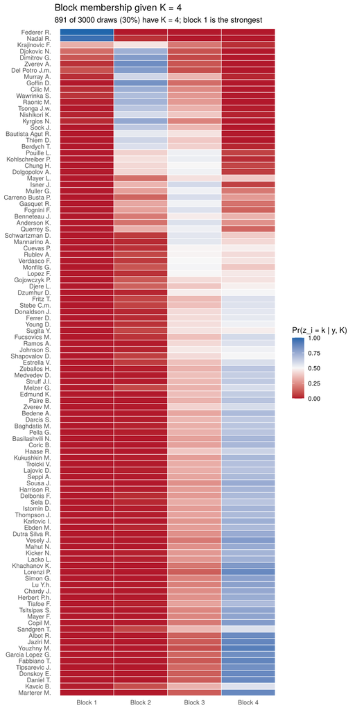

```r
plot_assignment_probabilities(atp_fit, clean_fun = NULL)
```

## 3.4 Who is stronger than whom among the top players?

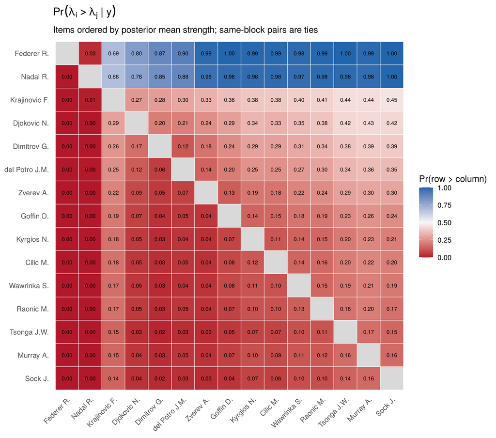

```r
plot_prob_stronger(atp_fit, max_items = 15)
```

Federer and Nadal are tied in most draws (they share the top block), so neither is “stronger” than the other with high probability. Below them, many probabilities sit between 0.1 and 0.45: these players share blocks in some draws and not in others. A player with few matches against the top 105 (look up Krajinović in `atp_players`) can have a high posterior mean but large uncertainty.

# 4 Rankings: the Plackett–Luce model

Rankings record items in order of preference rather than pairwise outcomes. The Plackett–Luce (PL) model chooses the first item with probability proportional to its strength, then the second among those remaining, and so on. For a first analysis we use the standard model, with one strength per item.

```r
sushi <- sushi_toy(n_rankings = 40, rank_length = 5, seed = 3)
sushi
```

```
## <btsbm_ranking_data> 40 rankings of length 5 from 10 items
```

```r
head(sushi$rankings, 3)
```

```
##           Rank_1 Rank_2 Rank_3 Rank_4 Rank_5
## Ranking_1      7      2     10      1      4
## Ranking_2      3      7      8      6      2
## Ranking_3      2      6      3      7      8
```

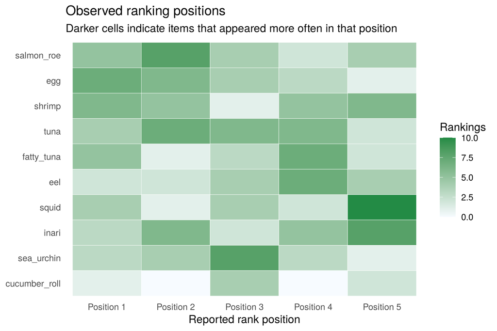

```r
plot_ranking_positions(sushi)
```

```r
pl_fit <- fit_model(sushi, pl_model(shape_lambda = 1, rate_lambda = 1),
                    mcmc_control(iter = 2000, warmup = 1000, seed = 4))
summary(pl_fit)
```

```
## Model:   Plackett-Luce (PL), one strength per item
## Data:    10 items, 40 rankings of length 5
## Priors:  lambda_i ~ iid Gamma(shape_lambda = 1, rate_lambda = 1)
## MCMC:    2000 iterations, 1000 warm-up, 1000 retained draws (2.3 s)
##
## Relative strengths (share of total strength), 90% credible intervals:
##           item  mean median lower upper
##           tuna 0.138  0.136 0.098 0.185
##     salmon_roe 0.124  0.122 0.087 0.166
##         shrimp 0.116  0.115 0.081 0.156
##            egg 0.115  0.114 0.079 0.156
##          inari 0.115  0.113 0.083 0.154
##          squid 0.094  0.093 0.063 0.129
##     sea_urchin 0.094  0.094 0.063 0.130
##            eel 0.086  0.084 0.058 0.119
##     fatty_tuna 0.086  0.085 0.054 0.118
##  cucumber_roll 0.030  0.029 0.015 0.049
```

As for BT, reported strengths are shares of total strength in each draw.

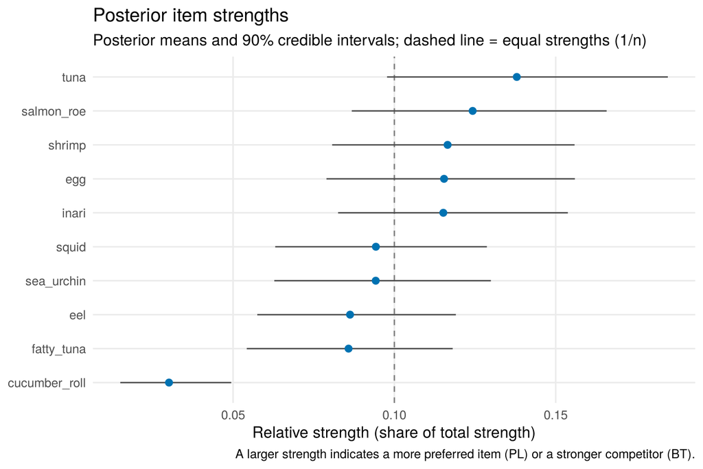

```r
plot_strength_summary(pl_fit)
```

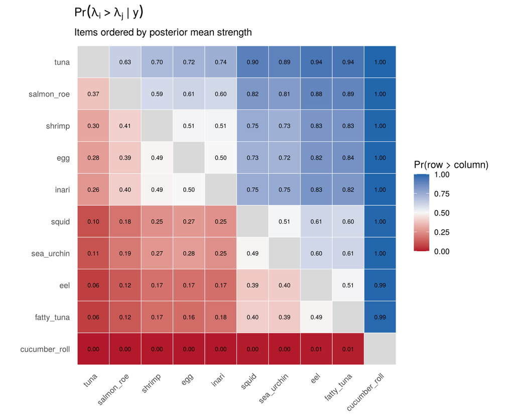

```r
plot_prob_stronger(pl_fit)
```

The same `fit_model()` call also fits PL models with item blocks (`pl_sbm_model()`), groups of rankers (`pl_mixture_model()`) or both (`pl_lbm_model()`); see `vignette("pl-ranking-models", package = "RBBayes")`.

# 5 Exercises

1. Simulate the synthetic league with `latent_strength = c(12, 9, 2, 1)`. How do the posterior of $K$ and the credible ball change? What does `block_stability()` now report?
2. Reduce `matches_per_pair` to 5. Which summaries change most?
3. Refit the ATP season with `gnedin_prior(gnedin_hyper = 0.8)` and with `dirichlet_process_prior(concentration = 1)`. Compare `prior_mean_K()` and `posterior_K_table()` for the two priors.
4. Choose another ATP season (e.g. `"2008"` or `"2023"`). Is the top tier larger or smaller than in 2017?